# cobertes

Lucía Martinez Maragreto

```r
library(sf)
library(dplyr)
library(tidyr)
library(ggplot2)
```

Es carreguen les capes de cobertes del sòl reclassificades corresponents a diferents anys.

```r
cob2009 <- st_read("dades/processades/cobertes_sol/cobertes-sol-v1r0-2009-reclas.gpkg")
cob2018 <- st_read("dades/processades/cobertes_sol/cobertes-sol-v1r0-2018-reclas.gpkg")
cob2019_2022 <- st_read("dades/processades/cobertes_sol/cobertes-sol-v1r0-2019-2022-reclas.gpkg")
cob2023 <- st_read("dades/processades/cobertes_sol/cobertes-sol-v1r0-2023-reclas.gpkg")
```

S’afegeix un identificador únic als punts i se seleccionen les variables essencials per a l’anàlisi espacial.

```r
sf_final <- st_read("dades/processades/sf_final.gpkg")
sf_final$ID <- 1:nrow(sf_final)
sf_curt <- sf_final %>% select(ID, INCENDI, ANY, geom)
```

Se simplifiquen les geometries de les cobertes del sòl per reduir el cost computacional de les interseccions.

```r
cob2009_simple <- st_simplify(cob2009, dTolerance = 50)
cob2018_simple <- st_simplify(cob2018, dTolerance = 50)
cob2019_2022_simple <- st_simplify(cob2019_2022, dTolerance = 50)
cob2023_simple <- st_simplify(cob2023, dTolerance = 50)
```

S’organitzen les capes de cobertes en una llista per facilitar-ne la selecció segons l’any d’estudi.

```r
cobertes <- list(
  "2009" = cob2009_simple,
  "2018" = cob2018_simple,
  "2022" = cob2019_2022_simple,
  "2023" = cob2023_simple
)
```

Es defineix una funció que retorna la capa de cobertes adequada en funció de l’any del punt.

```r
get_coberta <- function(any) {
  if (any <= 2009) cobertes[["2009"]]
  else if (any <= 2018) cobertes[["2018"]]
  else if (any <= 2022) cobertes[["2022"]]
  else cobertes[["2023"]]
}
```

Es calcula, per a cada any, la proporció de cada tipus de coberta del sòl dins d’un buffer de 500 metres al voltant del punt.

```r
resultats <- list()

for (any in sort(unique(sf_curt$ANY))) {

  message("Processant any: ", any)

  punts_any <- sf_curt %>% filter(ANY == any)
  buf_any <- st_buffer(punts_any, 500)

  cob_any <- get_coberta(any)

  inter <- st_intersection(buf_any, cob_any)
  inter$area <- st_area(inter)

  res_any <- inter %>%
    st_drop_geometry() %>%
    group_by(ID, TIPUS) %>%
    summarise(area = sum(area), .groups = "drop") %>%
    group_by(ID) %>%
    mutate(pct = area / sum(area)) %>%
    ungroup()


  resultats[[as.character(any)]] <- res_any
}
```

Es combinen els resultats anuals i es transformen en format ample.

```r
resultats_cobertes <- bind_rows(resultats) %>%
  mutate(pct = as.numeric(pct))

resultats_wide <- resultats_cobertes %>%
  select(ID, TIPUS, pct) %>%
  pivot_wider(
    names_from = TIPUS,
    values_from = pct,
    values_fill = 0
  )

punts_final <- sf_curt %>%
  left_join(resultats_wide, by = "ID")
```

Es repeteix el procediment d’intersecció espacial per obtenir les proporcions segons el tipus de combustible.

```r
resultats2 <- list()

for (any in sort(unique(sf_curt$ANY))) {

  message("Processant any: ", any)

  punts_any <- sf_curt %>% filter(ANY == any)
  buf_any <- st_buffer(punts_any, 500)

  cob_any <- get_coberta(any)

  inter <- st_intersection(buf_any, cob_any)
  inter$area <- st_area(inter)

  res_any <- inter %>%
    st_drop_geometry() %>%
    group_by(ID, COMBUST) %>%
    summarise(area = sum(area), .groups = "drop") %>%
    group_by(ID) %>%
    mutate(pct = area / sum(area)) %>%
    ungroup()


  resultats2[[as.character(any)]] <- res_any
}
```

Es genera una taula amb els percentatges de superfície per tipus de combustible associats a cada punt.

```r
resultats_cobertes2 <- bind_rows(resultats2) %>%
  mutate(pct = as.numeric(pct))

resultats_wide2 <- resultats_cobertes2 %>%
  select(ID, COMBUST, pct) %>%
  pivot_wider(
    names_from = COMBUST,
    values_from = pct,
    values_fill = 0
  )

punts_final2 <- sf_curt %>%
  left_join(resultats_wide2, by = "ID")
```

Es compara la composició mitjana de les cobertes del sòl entre punts amb incendi i sense.

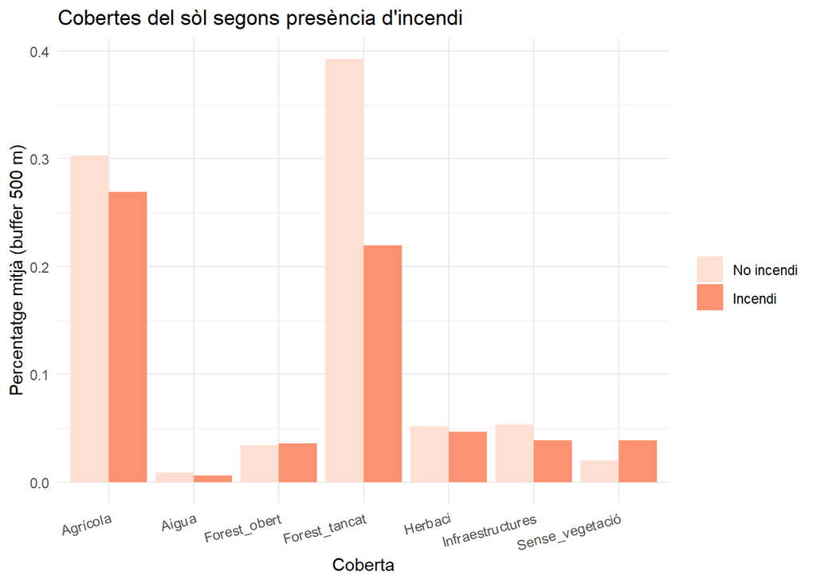

```r
punts_final %>%
  st_drop_geometry() %>%
  select(INCENDI, Forest_obert, Forest_tancat, Herbaci, Sense_vegetació,
         Agrícola, Infraestructures, Aigua) %>%
  pivot_longer(-INCENDI, names_to = "Coberta", values_to = "pct") %>%
  ggplot(aes(Coberta, pct, fill = factor(INCENDI))) +
  stat_summary(fun = mean, geom = "col", position = "dodge") +
  scale_fill_brewer(palette = "Reds", direction = 1,
                    labels = c("No incendi", "Incendi")) +
  labs(
    title = "Cobertes del sòl segons presència d'incendi",
    fill = "",
    y = "Percentatge mitjà (buffer 500 m)"
  ) +
  theme_minimal() +
  theme(axis.text.x = element_text(angle = 15, hjust = 1))
```

Es representa el percentatge mitjà de cada tipus de combustible en funció de la presència d’incendi.

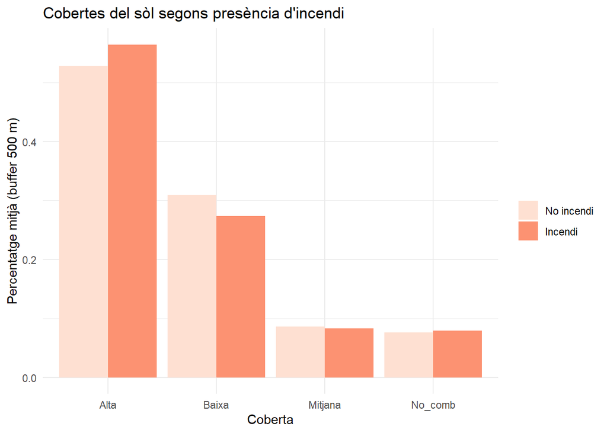

```r
punts_final2 %>%
  st_drop_geometry() %>%
  select(INCENDI, Alta, Mitjana, No_comb, Baixa) %>%
  pivot_longer(-INCENDI, names_to = "Coberta", values_to = "pct") %>%
  ggplot(aes(Coberta, pct, fill = factor(INCENDI))) +
  stat_summary(fun = mean, geom = "col", position = "dodge") +
  scale_fill_brewer(palette = "Reds", direction = 1,
                    labels = c("No incendi", "Incendi")) +
  labs(
    title = "Cobertes del sòl segons presència d'incendi",
    fill = "",
    y = "Percentatge mitjà (buffer 500 m)"
  ) +
  theme_minimal()
```